# Visualizing thermal comfort simulation outputs from EnergyPlus

A guide to visualizing and interpreting thermal comfort simulation outputs

Chitra Nambiar, Tobias Kramer, Stefano Schiavon, *Center for the Built Environment, UC Berkeley

2026-11-13

## Introduction

Whole-building simulation programs such as [EnergyPlus](https://energyplus.net/) (Crawley et al. 2001) generate detailed outputs of indoor thermal conditions under different weather, envelope, and HVAC operating conditions. They can report comfort indices such as the Predicted Mean Vote (PMV),operative temperature, and standard effective temperature (SET) for each zone and time step. However, translating these large datasets into meaningful visualizations that help users interpret spatial and temporal patterns in thermal comfort remains challenging. There is limited guidance on how to effectively visualize and interpret thermal comfort outputs from building simulations. This guide presents a set of visualizations organized around five practitioner questions to translate hourly thermal comfort outputs into accessible, actionable insights for design evaluation, operational decision-making, and stakeholder communication.

**Scope.** The visualizations suggested in this guide are designed to address common questions that arise when evaluating thermal comfort using hourly building simulation results. It is applicable to a wide range of building types, climates, and operational strategies. The comfort variables and visualizations presented here are based on Fangers PMV/PPD (Fanger 1972) method used in ASHRAE 55 (ASHRAE 2023) and ISO 7730:2005 (ISO 2005) and operative temperatures. However, the general data processing workflow can apply to other EnergyPlus comfort outputs, including SET from the Pierce two-node model (Gagge et al. 1986) and the ASHRAE 55 adaptive model (Dear and Brager 1998). The visualizations presented here are organized around four questions: where discomfort occurs, when it occurs, how often it occurs, and why or what may be causing to it. Any of the visualizations can be also be used to compare how results differ between design or operating scenarios.

The guide does not propose comfort models or define acceptable comfort conditions. All thresholds and targets used here are illustrative and should be set for each project per the specific requirements and context. For detailed information on thermal comfort theory, please refer to the ASHRAE 55 standards(ASHRAE 2023) and related literature [Thermal comfort](https://en.wikipedia.org/wiki/Thermal_comfort).

Use the matrix to choose a visualization based on the question you need to answer. Each section below addresses one of these questions:

| Question | Primary visualization | Section |  |
| --- | --- | --- | --- |
| **Where** does discomfort occur? | Zone comfort scorecard | 1 |  |
| **When** does discomfort occur? | Carpet plot | 2 |  |
| **How often** does discomfort occur? | Distribution plots | 3 |  |
| **Why** does discomfort occur? | Event time series | 4 |  |
| **Comparing designs or scenarios** | Any of the above | 5 |  |

### Prerequisites

- **R 4.1** with `tidyverse`, `lubridate`, `patchwork`, `scales`, and `here`. Uncomment the `install.packages()` line in the setup chunk to install them for the first time.
- **EnergyPlus simulation** with hourly `Output:Variable` requests for the variables listed in the Data Import section set to `Hourly` frequency. These must be specified in the EnergyPlus IDF before running the simulation. For further details on EnergyPlus simulation setup, please refer to the [EnergyPlus documentation](https://energyplus.net/documentation). Information about thermal comfort models and their implementation in EnergyPlus can be found in the [EnergyPlus Input Output Reference](https://energyplus.net/documentation/input-output-reference).

### Steps to use this markdown document

1. Run your EnergyPlus simulation using one of the thermal comfort models (e.g., Fanger, Pierce, Adaptive comfort) in the “People” object and with the required `Output:Variable` entries in your IDF.
2. Place this `.Rmd` in a project folder and the EnergyPlus output CSV in the `sims/` subfolder. Update `csv_file` in the data-import chunk with actual filename.
3. Update inputs in the ‘setup’ and ‘data-setup’ chunks (marked ###User input###).
4. Click **Knit**. The report displays the plots; individual plot chunks also save selected figures as PNG files in the working directory.

**Data import**

The ‘data-import’ chunk reads the EnergyPlus hourly CSV. The `process_df()` function in the ‘data-setup’ chunk below parses timestamps, reshapes zone variables, and creates the shorter names used by the plots. The featured example in this guide is based on a [small office building model](https://www.energycodes.gov/prototype-building-models#Commercial) with five zones (one core and four perimeter zones) (C Nambiar et al. 2024). The Fanger thermal comfort model (Fanger 1972) is used in this example.

**Timestamps.** EnergyPlus reports hour-ending timestamps (e.g., `07:00:00` is the average over 06:00–07:00, and the last hour of each day is stamped `24:00:00`). `process_df()` converts each timestamp to the start of its interval, so throughout this guide hour 6 means 06:00–07:00, and the carpet plots draw that hour as the band between 6 and 7 on the y-axis.

**Before knitting:** Place the CSV in the `sims/` folder, or update `csv_file` below to point to the correct file.

**Required EnergyPlus `Output:Variable` entries** (add these to your IDF, all at `Hourly` frequency):

| EnergyPlus variable | Used for |
| --- | --- |
| `Environment:Site Outdoor Air Drybulb Temperature [C]` | Outdoor reference temperature |
| `Environment:Site Outdoor Air Relative Humidity [%]` | Outdoor humidity reference |
| `Zone People Occupant Count []` | Filtering to occupied hours |
| `Zone Operative Temperature [C]` | Comfort metric (all zones) |
| `Zone Air Relative Humidity [%]` | Indoor humidity (all zones) |
| `Zone Thermal Comfort Fanger Model PMV []` | PMV comfort categorization |

| Additional variables to consider for additional analysis |
| --- |
| `Zone Thermal Comfort Pierce Model Standard Effective Temperature [C]` |
| `Zone Thermal Comfort ASHRAE 55 Adaptive Model Running Average Outdoor Air Temperature [C]` |
| `Cooling:Electricity [J]` |
| `Heating:Electricity [J]` |

**Call functions:** Call plotting functions in the subsequent chunks to generate the visualizations. Each function returns a ggplot object and saves a PNG file if `config$save_plots` is TRUE.

# 1. Where does discomfort occur?

Use this scorecard as a screening step to compare building-wide and zone-specific comfort performance and quickly pinpoint zones that may need further investigation.

**Zone comfort scorecard** displays the overall comfort performance across the simulation runtime. Two options are featured below: a scorecard based on PMV bands (Fanger 1972), and a second based on indoor operative temperature bands.Each row represents a zone and the color bands indicate the share of occupied hours in each comfort category. PMV band between -0.5 to +0.5 PMV is considered comfortable; values below this band are classified as cool discomfort and above as warm discomfort. Operative temperature bands are set at <20°C (cool), 20–25°C (comfortable), and >25°C (warm). The comfort bands can be adjusted in the configuration file per project requirements.

Call `plot_pmv_bands()` or `plot_top_bands()` to generate the scorecard for PMV or operative temperature, respectively.

To interpret the results, compare the comfortable-hour share across zones, then check whether the remaining hours are mostly too cool or too warm. A zone that stands out from similar zones points to a zone-specific cause (orientation, glazing, exposure, an undersized terminal unit). When every zone shows the same pattern, potential causes for discomfort are likely building-wide, for example a setpoint or schedule issue.

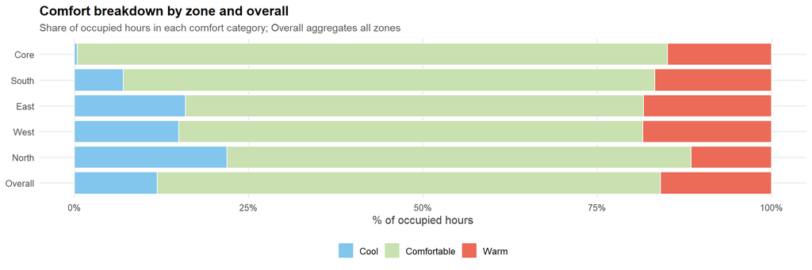

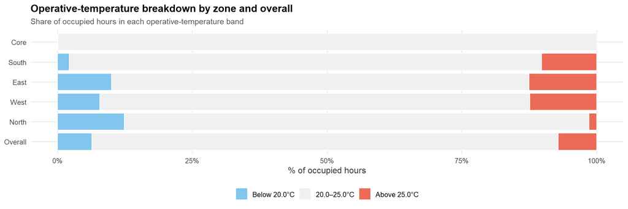

The operative-temperature scorecard shows similar patterns as the PMV but with higher share of occupied hours within the selected operative temperature band of 20–25°C. The difference between the PMV and operative-temperature scorecards are expected as the PMV comfort result is sensitive to occupant inputs (clothing and metabolic activity), which are not captured in the operative temperature calculation.

# 2. When does discomfort occur?

To identify when the a zone experiences comfortable, cool or warm discomfort, use carpet plots. They display the comfort status of a selected zone over every simulation timestep to help visualize the temporal distribution of comfort conditions. Carpet plots based on PMV bands, operative temperature bands, and relative humidity are shown below. They are accompanied by a percentage bar that shows the share of occupied hours in each comfort category. The carpet plots can be used to identify seasonal patterns and daily patterns during occupied hours.

### Daily and hourly pattern: carpet plots

**Carpet plot** In this heatmap or carpet plot, each column is a day and each row is an hour. It shows both time-of-day patterns (morning start-up, afternoon solar gain) and seasonal patterns (summer vs. winter) simultaneously for the selected zone specified in the ‘setup’ and ‘data-setup’ chunks above. For the PMV carpet plot, blue color cells indicate PMV values below the comfort range (cool discomfort), green cells indicate PMV values within the comfort range, and red cells indicate PMV values above the comfort range (warm discomfort). For the operative temperature carpet plot, blue cells indicate temperatures below 20°C, white cells indicate temperatures within 20-25°C, and red gradient cells indicate temperatures above 25°C. Comparing both plots helps identify periods where discomfort may be driven by assumptions in the thermal comfort model (clothing, activity assumptions in PMV model) vs other factors such as solar gains, thermostat settings, or ventilation.

Call `plot_annual_heatmap()`, `plot_annual_top_heatmap()`, or `plot_annual_rh_heatmap()` to generate the carpet plots for PMV, operative temperature, or relative humidity, respectively.

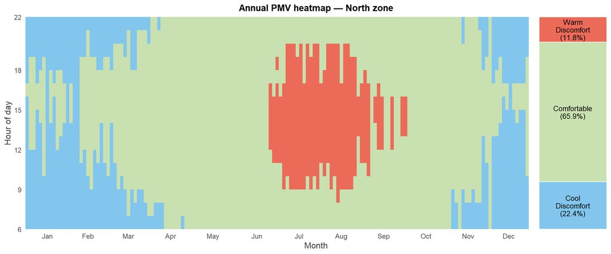

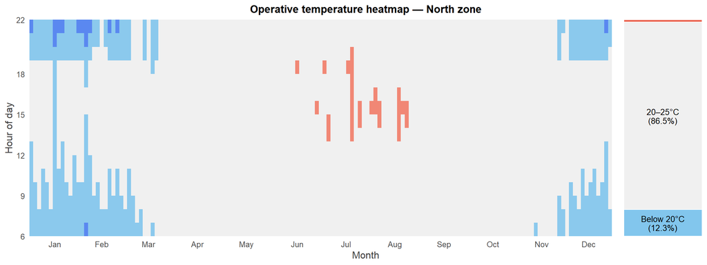

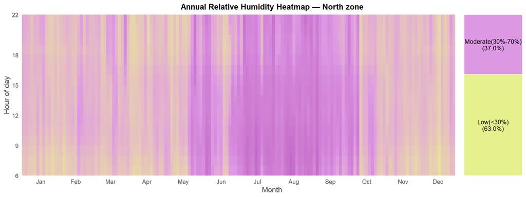

```r
print(plot_annual_heatmap(data, config,
  bar_gap = 3,
  bar_width = 20
))
```

**In this example.** In winter (Nov–Mar), the north zone has cool discomfort mainly in the early morning and from about 19:00 onward. Operative temperature falls below 20 °C over the same hours, which points to slow morning warm-up and a schedule-driven drop in the evening. In summer (Jun–Sep), PMV shows warm discomfort from roughly 09:00 to 20:00, but operative temperature rarely goes above 25 °C (1.1% of hours). So the summer warm discomfort comes from the other PMV inputs such as clothing and activity levels rather than from air temperature alone. The relative humidity carpet plot shows that some days in winter the north zone experience low humidity in addition to low temperatures which may also be contributing to cool PMV band hours.

# 3. How often does discomfort occur?

Use the distribution plots below to compare each zone with a project-defined target, such as 80% of occupied hours within the selected comfort band. The target and the comfort criteria should be stated explicitly for the project.

### Distribution of operative temperature

Call `plot_top_distribution()` to generate the operative temperature distribution plot and summary table.

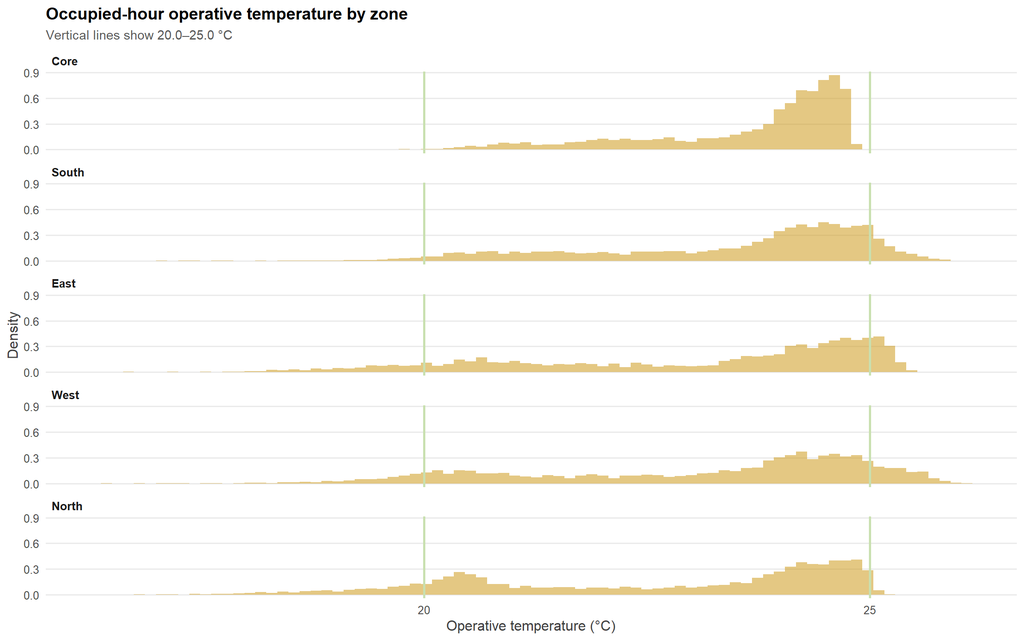

```r
top_distribution <- plot_top_distribution(data, config)
top_distribution$plot
```

**In this example.** Each zone peaks near 24-25°C. Core and North zones hold cooling at 25°C, while South, East and West zones extend past this limit likely due to solar gain from walls and windows which raises the mean radiant temperature pushing operative temperature above the air setpoint. North,and west also show a secondary peak near 20–21 °C and a tail below 20 °C matching the cool discomfort share seen in the scorecard plot.

```r
knitr::kable(top_distribution$summary |> mutate(
  pct_hours_in_range = scales::percent(pct_hours_in_range, accuracy = 0.1)) |>
    rename(
      Zone = zone_label,
      #`Hours in range` = hours_in_range,
      #`Occupied hours with data` = total_hours,
      `% occupied hours in range` = pct_hours_in_range
    ) |> select(Zone, `% occupied hours in range`),
  caption = sprintf("Occupied hours with operative temperature between %.1f and %.1f °C", config$top_band[1], config$top_band[2])
)
```

Occupied hours with operative temperature between 20.0 and 25.0 °C

| Zone | % occupied hours in range |
| --- | --- |
| Core | 99.9% |
| South | 87.6% |
| East | 77.5% |
| West | 79.8% |
| North | 86.2% |

The same data can be visualized in a different way using a whisker plot to show the distribution of operative temperature for each zone. The points mark monthly medians and the whiskers span the 5th to 95th percentiles. Wider ranges indicate greater variation in occupied-hour operative temperature. The plot shows how often each zone sits near or beyond the limits.

Call `plot_monthly_top()` to generate the operative temperature whisker plot.

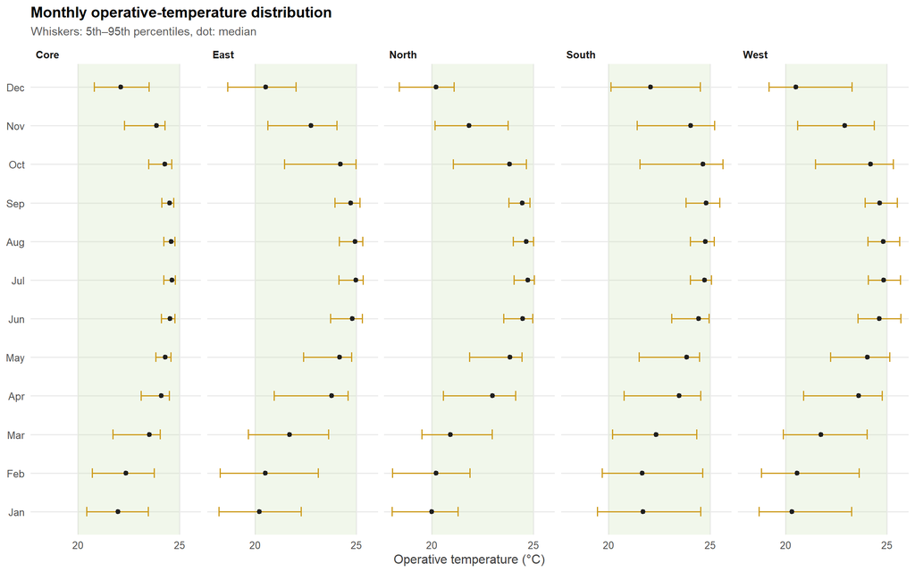

```r
plot_monthly_top(data, config)
```

# 4. Why does discomfort occur?

An event time series plot can help identify potential reasons for discomfort identified during a period of interest identified in the earlier plots. For example, the carpet plots showed insufficient heating in the morning and evening in winter; comparing zone and outdoor conditions over the same hours may test possible explanations. **Event time series:** Pick a representative period from carpet plot (here, one week) and plot the comfort result alongside its likely drivers on a shared time axis. The top panel shows outdoor and zone operative temperature, the bottom panel shows PMV against the comfort band, and grey shading marks occupied hours.

Call `plot_event()` to generate the event time series plot. The function can also compare other reported variables such as outdoor temperature, relative humidity, or solar radiation. The comparison variable(s) can be overlaid on the temperature panel or plotted in a separate panel below the temperature panel.

### Example: Compare winter cool discomfort in north zone vs core zone

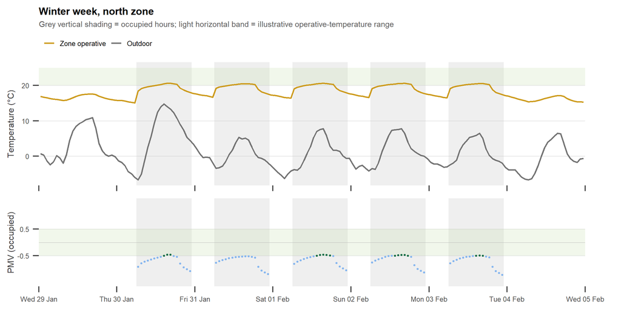

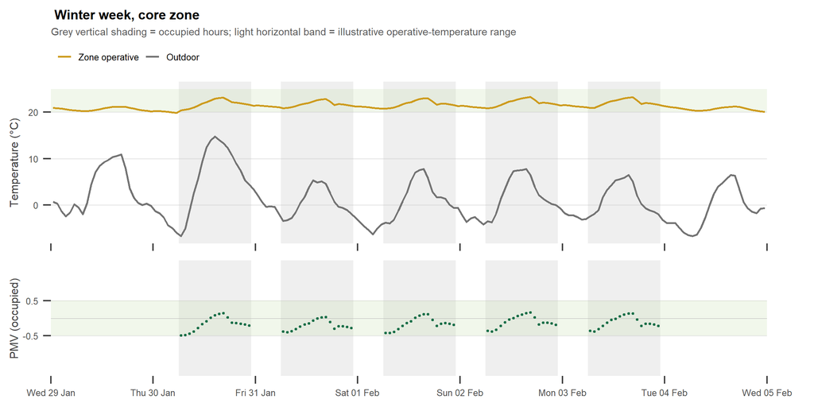

# 5. Comparing designs or scenarios

For design or operating comparisons, apply the same data processing, comfort criteria, occupied-hour filters, and compare visualizations between both scenarios. The following example compares the original model with a revised clothing schedule to isolate the effect of occupant assumptions in the PMV results. The revised schedule is a four-step schedule: 1.1 clo from 1 January to 30 March, 1.0 clo to 30 June, 0.7 clo to 15 September, and 1.1 clo to 31 December. Because clothing does not enter the EnergyPlus zone heat balance, operative temperatures are identical; only the comfort calculation changes.

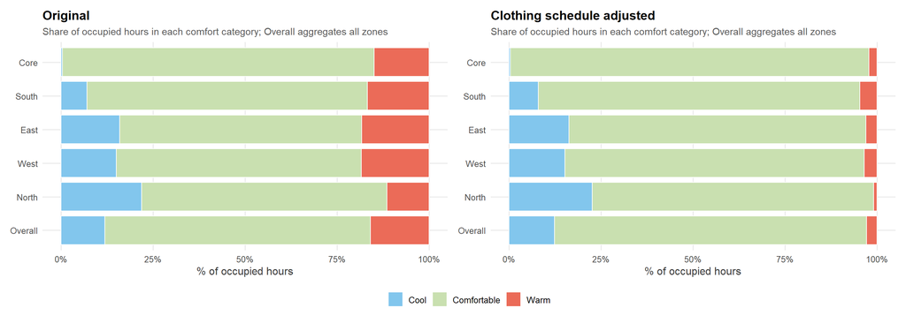

Stacked comfort comparison: #original and clothing-adjusted scenarios.

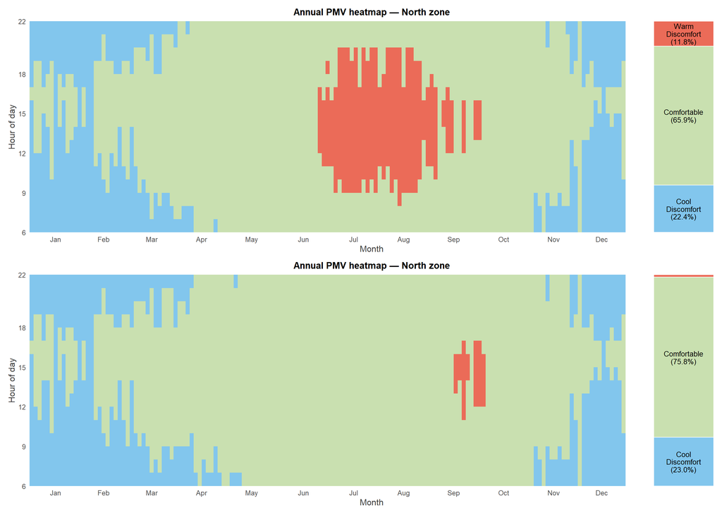

Annual heatmap comparison: original and clothing-adjusted scenarios.

**In this example.** The comfortable share rises in every zone, almost entirely because summer warm discomfort disappears; cool discomfort is essentially unchanged because it is driven by low winter temperatures rather than by clothing. A small new warm cluster appears in late September in the north zone, where the schedule steps from 0.7 to 1.1 clo while indoor temperatures are still near 24.5 °C, an artifact of abrupt step changes. PMV results should therefore be reported together with their clothing assumptions which could context-specific (Schiavon and Lee 2013).

**Suggested citation**

Code: https://github.com/CenterForTheBuiltEnvironment/comfortvisuals.git License: CC BY 4.0 for text, MIT for code

## References

ASHRAE. 2023. *Thermal Environmental Conditions for Human Occupancy*. ANSI/ASHRAE Standard Nos. 55-2023. American Society of Heating, Refrigerating; Air-Conditioning Engineers.

C Nambiar, Chitra, Michael I. Rosenberg, Douglas E. Maddox, et al. 2024. *Commercial Building Prototypes Based on ANSI/ASHRAE/IES Standard 90.1-2019 Appendix g PRM: Technical Support Document*. Pacific Northwest National Laboratory (PNNL), Richland, WA (United States). https://doi.org/10.2172/2476528.

Carlucci, Salvatore, and Lorenzo Pagliano. 2012. “A Review of Indices for the Long-Term Evaluation of the General Thermal Comfort Conditions in Buildings.” *Energy and Buildings* 53: 194–205. https://doi.org/10.1016/j.enbuild.2012.06.015.

Crawley, Drury B., Linda K. Lawrie, Frederick C. Winkelmann, et al. 2001. “EnergyPlus: Creating a New-Generation Building Energy Simulation Program.” *Energy and Buildings* 33 (4): 319–31. https://doi.org/10.1016/S0378-7788(00)00114-6.

Dear, Richard J. de, and Gail S. Brager. 1998. “Developing an Adaptive Model of Thermal Comfort and Preference.” *ASHRAE Transactions* 104 (1): 145–67.

Fanger, P. O. 1972. *Thermal Comfort: Analysis and Applications in Environmental Engineering*. McGraw-Hill.

Gagge, A. P., A. P. Fobelets, and L. G. Berglund. 1986. “A Standard Predictive Index of Human Response to the Thermal Environment.” *ASHRAE Transactions* 92 (2B): 709–31.

ISO. 2005. *Ergonomics of the Thermal Environment — Analytical Determination and Interpretation of Thermal Comfort Using Calculation of the PMV and PPD Indices and Local Thermal Comfort Criteria*. Standard ISO 7730:2005. International Organization for Standardization.